# Explore_bikeshare_data

### Explore Bike Share Data

For this project, your goal is to ask and answer three questions about the available bikeshare data from Washington, Chicago, and New York. This notebook can be submitted directly through the workspace when you are confident in your results.

You will be graded against the project [Rubric](https://review.udacity.com/#!/rubrics/2508/view) by a mentor after you have submitted. To get you started, you can use the template below, but feel free to be creative in your solutions!

```r
ny = read.csv('new_york_city.csv')
wash = read.csv('washington.csv')
chi = read.csv('chicago.csv')
```

```r
head(ny)
```

| X | Start.Time | End.Time | Trip.Duration | Start.Station | End.Station | User.Type | Gender | Birth.Year |
| --- | --- | --- | --- | --- | --- | --- | --- | --- |
| 5688089 | 2017-06-11 14:55:05 | 2017-06-11 15:08:21 | 795 | Suffolk St & Stanton St | W Broadway & Spring St | Subscriber | Male | 1998 |
| 4096714 | 2017-05-11 15:30:11 | 2017-05-11 15:41:43 | 692 | Lexington Ave & E 63 St | 1 Ave & E 78 St | Subscriber | Male | 1981 |
| 2173887 | 2017-03-29 13:26:26 | 2017-03-29 13:48:31 | 1325 | 1 Pl & Clinton St | Henry St & Degraw St | Subscriber | Male | 1987 |
| 3945638 | 2017-05-08 19:47:18 | 2017-05-08 19:59:01 | 703 | Barrow St & Hudson St | W 20 St & 8 Ave | Subscriber | Female | 1986 |
| 6208972 | 2017-06-21 07:49:16 | 2017-06-21 07:54:46 | 329 | 1 Ave & E 44 St | E 53 St & 3 Ave | Subscriber | Male | 1992 |
| 1285652 | 2017-02-22 18:55:24 | 2017-02-22 19:12:03 | 998 | State St & Smith St | Bond St & Fulton St | Subscriber | Male | 1986 |

```r
head(wash)
```

| X | Start.Time | End.Time | Trip.Duration | Start.Station | End.Station | User.Type |
| --- | --- | --- | --- | --- | --- | --- |
| 1621326 | 2017-06-21 08:36:34 | 2017-06-21 08:44:43 | 489.066 | 14th & Belmont St NW | 15th & K St NW | Subscriber |
| 482740 | 2017-03-11 10:40:00 | 2017-03-11 10:46:00 | 402.549 | Yuma St & Tenley Circle NW | Connecticut Ave & Yuma St NW | Subscriber |
| 1330037 | 2017-05-30 01:02:59 | 2017-05-30 01:13:37 | 637.251 | 17th St & Massachusetts Ave NW | 5th & K St NW | Subscriber |
| 665458 | 2017-04-02 07:48:35 | 2017-04-02 08:19:03 | 1827.341 | Constitution Ave & 2nd St NW/DOL | M St & Pennsylvania Ave NW | Customer |
| 1481135 | 2017-06-10 08:36:28 | 2017-06-10 09:02:17 | 1549.427 | Henry Bacon Dr & Lincoln Memorial Circle NW | Maine Ave & 7th St SW | Subscriber |
| 1148202 | 2017-05-14 07:18:18 | 2017-05-14 07:24:56 | 398.000 | 1st & K St SE | Eastern Market Metro / Pennsylvania Ave & 7th St SE | Subscriber |

```r
head(chi)
```

| X | Start.Time | End.Time | Trip.Duration | Start.Station | End.Station | User.Type | Gender | Birth.Year |
| --- | --- | --- | --- | --- | --- | --- | --- | --- |
| 1423854 | 2017-06-23 15:09:32 | 2017-06-23 15:14:53 | 321 | Wood St & Hubbard St | Damen Ave & Chicago Ave | Subscriber | Male | 1992 |
| 955915 | 2017-05-25 18:19:03 | 2017-05-25 18:45:53 | 1610 | Theater on the Lake | Sheffield Ave & Waveland Ave | Subscriber | Female | 1992 |
| 9031 | 2017-01-04 08:27:49 | 2017-01-04 08:34:45 | 416 | May St & Taylor St | Wood St & Taylor St | Subscriber | Male | 1981 |
| 304487 | 2017-03-06 13:49:38 | 2017-03-06 13:55:28 | 350 | Christiana Ave & Lawrence Ave | St. Louis Ave & Balmoral Ave | Subscriber | Male | 1986 |
| 45207 | 2017-01-17 14:53:07 | 2017-01-17 15:02:01 | 534 | Clark St & Randolph St | Desplaines St & Jackson Blvd | Subscriber | Male | 1975 |
| 1473887 | 2017-06-26 09:01:20 | 2017-06-26 09:11:06 | 586 | Clinton St & Washington Blvd | Canal St & Taylor St | Subscriber | Male | 1990 |

### Question 1

Which gender from New York spend the most total time riding? What is the average time spent per ride by gender?

| Gender | Total.Trip.Duration |
| --- | --- |
|  | NA |
| Female | 10651022 |
| Male | 28604515 |

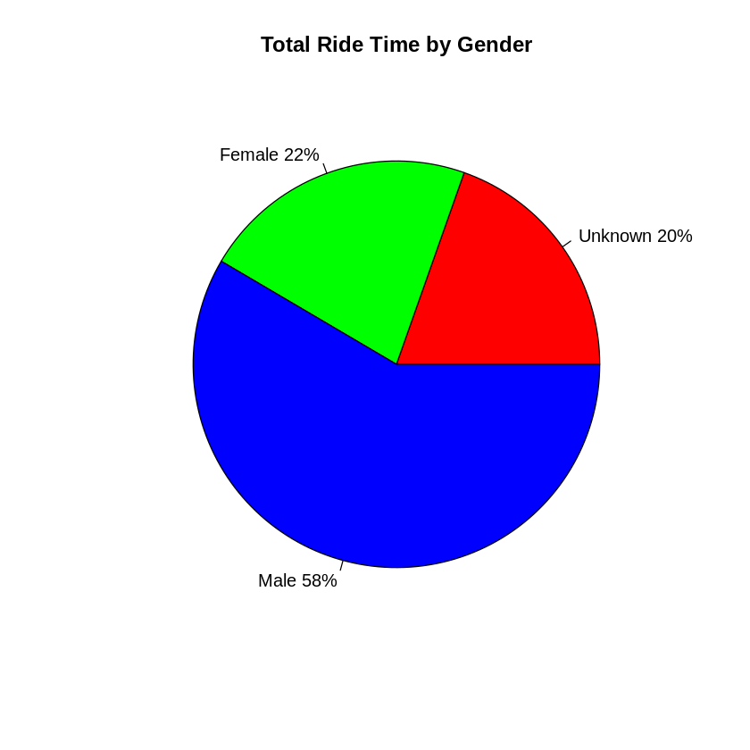

```r
##Loading relevant r-packages
library(magrittr)
library(dplyr)

##Finding the gender with the most rides
highest.rider.ny = ny %>% group_by(Gender) %>% summarise(Total.Trip.Duration = sum(Trip.Duration) )
highest.rider.ny

##Ploting a Pie Chart for the representation
slices = c(52884891, 59218793, 157801564)
lbls = c("Unknown", "Female", "Male")

parts = round(slices/sum(slices)*100)
lbls = paste(lbls, parts)
lbls = paste(lbls,"%",sep="")
pie(slices,labels = lbls, col=rainbow(length(lbls)),
    main="Total Ride Time by Gender")
```

| Gender | Total.Trip.Duration |
| --- | --- |
|  | NA |
| Female | 875.9785 |
| Male | 768.9179 |

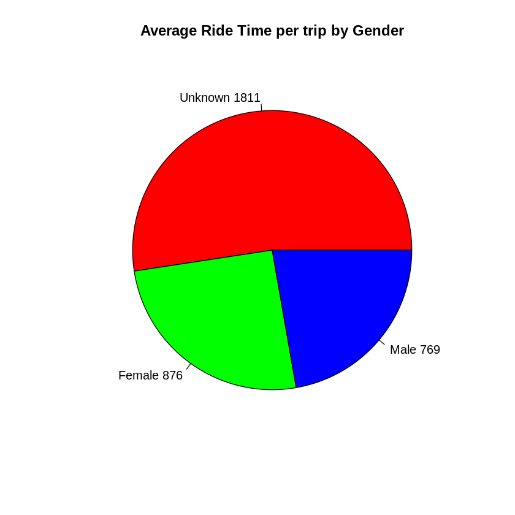

```r
##Loading relevant r-packages
library(magrittr)
library(dplyr)

##Finding the gender which spends the most riding time
average.travel.ny = ny %>% group_by(Gender) %>% summarise(Total.Trip.Duration = mean(Trip.Duration) )
average.travel.ny

##Ploting a Pie Chart for the representation
slices = c(1811, 875.9785, 768.9179)
lbls = c("Unknown", "Female", "Male")
parts = round(slices)
lbls = paste(lbls, parts)
pie(slices,labels = lbls, col=rainbow(length(lbls)),
    main="Average Ride Time per trip by Gender")
```

### Question 2

What are the top three start locations that bikers in Chicago frequently start their riding journey? Based on the proportion of trips starting from there, are they the favourite starting points for bike trips in Chicago?

| Start.Station | Number.of.bike.trips |
| --- | --- |
| Streeter Dr & Grand Ave | 210 |
| Lake Shore Dr & Monroe St | 140 |
| Clinton St & Washington Blvd | 120 |

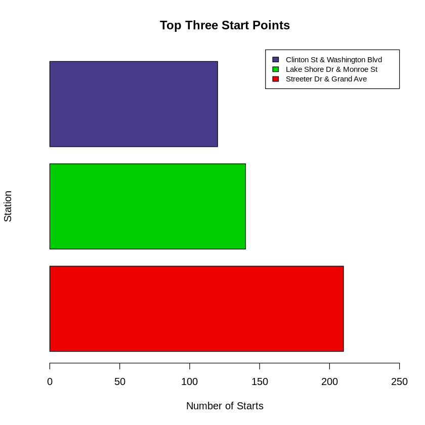

```r
##Reading the Chicago bikeshare data
chi = read.csv('chicago.csv')

##Loading relevant r-packages
library(magrittr)
library(dplyr)

##Finding the top three(3) favourite Start Stations
oldest.rider.chi = chi %>% group_by(Start.Station) %>% summarise(Number.of.bike.trips=n())
arranged.oldest.rider.chi=oldest.rider.chi %>% arrange(desc(Number.of.bike.trips))
top.arranged.oldest.rider.chi = arranged.oldest.rider.chi %>% top_n(3)
top.arranged.oldest.rider.chi

##Plotting a Bar Graph
numbik = c(210,140,120)
barplot(numbik, main = "Top Three Start Points", xlab = "Number of Starts", ylab = "Station", horiz=T, xlim = c(0,250), col=c("red2", "green3", "slateblue4"),legend.text = c("Streeter Dr & Grand Ave","Lake Shore Dr & Monroe St","Clinton St & Washington Blvd"),args.legend=list(cex=0.75,x="topright") )
```

1. 2.43337195828505

2. 1.62224797219003

3. 1.39049826187717

4. 94.5538818076477

[figure not shown]

```r
##Reading the Chicago bikeshare data
chi = read.csv('chicago.csv')

##Loading relevant r-packages
library(magrittr)
library(dplyr)

##Finding the percentage of the top three start points and the rest out of the total data
total = nrow(chi)
numbik = c(210,140,120,total-(210+140+120))


    ##Using a function to find the percentage
    numbik_to_percent = function(temp_N) {
      temp_P = (temp_N/total)*100
      return(temp_P)
    }

    ##Generating the values from the function
    slice_for_pie=numbik_to_percent(numbik)
    slice_for_pie

##Ploting a Pie Chart for the representation
slices = slice_for_pie
lbls = c("Clinton St & Washington Blvd", "Lake Shore Dr & Monroe St", "Streeter Dr & Grand Ave", "The Rest")

parts = round(slices/sum(slices)*100, digits=2)
lbls = paste(lbls, parts)
lbls = paste(lbls,"%",sep="")
pie(slices,labels = lbls, col=rainbow(length(lbls)),
    main="Percentage Representation of the Preferred Start Points")
legend("topright",legend=lbls, col=rainbow(length(lbls)),fill=rainbow(length(lbls)))
```

The top three start point turn out to be "Streeter Dr & Grand Avenue", "Lake Shore DR & Monroe St" and "Clinton St & Washington Blvd". 210 bike trips started from "Streeter Dr & Grand Avenue", 140 trips started from "Lake Shore DR & Monroe St" and 120 trips started from "Clinton St & Washington Blvd".

However, we could not say these three are favourite starting points since they do not together consist up to half of the start point. 2.43% of the bike trips started from "Streeter Dr & Grand Avenue", 1.62% started from "Lake Shore DR & Monroe St" and 1.39% started from "Clinton St & Washington Blvd". They just form 5.5% of the overall.

Thus though, these three are the top three, we cannot conclude they are the favourite start points.

### Question 3

Which type of rider from Washington rides less?

| User.Type | Total.Trip.Duration |
| --- | --- |
|  | NA |
| Customer | 2634.429 |
| Subscriber | 733.326 |

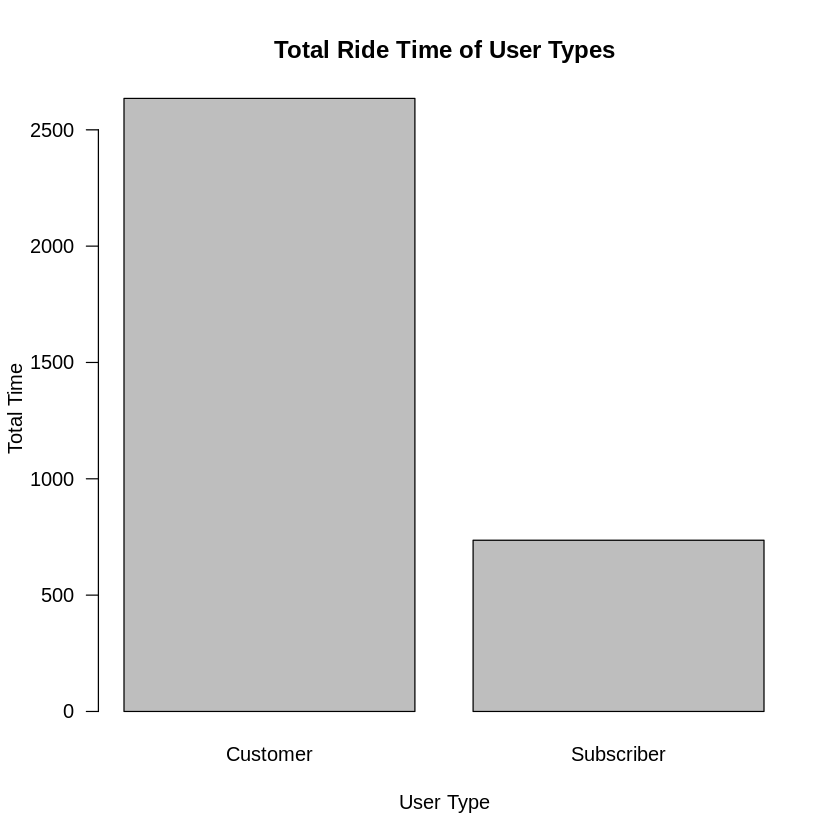

```r
##Loading relevant r-packages
library(magrittr)
library(dplyr)



##Finding the user with the average ride per User Type
low.rides.wash = wash %>% group_by(User.Type) %>% summarise(Total.Trip.Duration = mean(Trip.Duration) )
low.rides.wash

##Plotting a Bar Graph
numbik=c(2635,736)
barplot(numbik, main = "Total Ride Time of User Types", xlab = "User Type", ylab = "Total Time",las=1,names.arg = c("Customer","Subscriber") )
```

## Finishing Up

> Congratulations! You have reached the end of the Explore Bikeshare Data Project. You should be very proud of all you have accomplished!

> **Tip**: Once you are satisfied with your work here, check over your report to make sure that it is satisfies all the areas of the [rubric](https://review.udacity.com/#!/rubrics/2508/view).

## Directions to Submit

> Before you submit your project, you need to create a .html or .pdf version of this notebook in the workspace here. To do that, run the code cell below. If it worked correctly, you should get a return code of 0, and you should see the generated .html file in the workspace directory (click on the orange Jupyter icon in the upper left).

> Alternatively, you can download this report as .html via the **File** > **Download as** submenu, and then manually upload it into the workspace directory by clicking on the orange Jupyter icon in the upper left, then using the Upload button.

> Once you've done this, you can submit your project by clicking on the "Submit Project" button in the lower right here. This will create and submit a zip file with this .ipynb doc and the .html or .pdf version you created. Congratulations!

```r
system('python -m nbconvert Explore_bikeshare_data.ipynb')
```